# Gene Covariate Testing

Sneha M. Chaturvedi

Last updated 2026-09-04

Tests whether technical and biological covariates (gestational week, cell count, sex, batch1 fraction) predict pseudobulk gene expression across cell types. Used to determine which covariates to include in downstream limma models.

| **Inputs** | `data/cache/pb_base.rds`, `data/cache/batch_props_sample.rds` |
| --- | --- |
| **Outputs** | Regression results and volcano plots in `results/gene-hormone/covariate_analysis/` |
| **Upstream** | `prep_data.R` |
| **Downstream** | Informs model specification for hormone–gene limma scripts |

## Goals

Test whether sample-level covariates predict pseudobulk gene expression at the whole-transcriptome level. Results justify covariate inclusion in downstream limma-voom hormone ~ gene models.

**Covariates tested:**

- **Gestational Week (GW)**
- **Cell Count** — investigated as sample covariate and confounder
- **Sex (XX / XY)**
- **Batch** — investigated as potential technical confound

## Set Up

### Load packages

```r
Packages <- c(
  "tidyverse", "Seurat", "Signac", "glue", "readxl", "cowplot",
  "edgeR", "limma", "patchwork", "svglite", "Matrix", "ggpubr"
)
lapply(Packages, library, character.only = TRUE)

source("pseudobulk_functions.R")
root <- find_project_root()

set.seed(123)
```

### Load data

```r
pb_base <- readRDS(file.path(root, "data/cache/pb_base.rds"))
batch_props_sample <- readRDS(file.path(root, "data/cache/batch_props_sample.rds"))
```

```r
targeted_comparison_raw <- read_xlsx(file.path(root, "doc/targeted/targeted_hormones.xlsx"))

targeted_comparison_raw$TT <- targeted_comparison_raw$`TT (ng/mL)`
targeted_comparison_raw$P4 <- targeted_comparison_raw$`P4 (ng/mL)`
targeted_comparison_raw$E2 <- targeted_comparison_raw$`17B-E2 (ng/mL)`
```

### Generate pseudobulk *(min 30 cells per cell type for a sample to be included)*

```r
celltype_col <- "celltype"
sample_col <- "Sample"
pb_sample_pattern <- "tissue\\d+"
```

```r
pb_total <- merge_hormone_metadata(
  pb_base,
  targeted_comparison_raw,
  pb_sample_pattern = pb_sample_pattern,
  min_cells         = 30
)
```

### Compute per-sample batch composition *(used in Batch section)*

```r
# Join batch1_frac onto pb_total$metadata for use in perform_regression()
pb_total$metadata <- pb_total$metadata %>%
  tibble::rownames_to_column("pseudobulk_id") %>%
  dplyr::left_join(batch_props_sample,
by           = c("sample_id" = "Sample"),
relationship = "many-to-one"
  ) %>%
  tibble::column_to_rownames("pseudobulk_id")
```

## Gestational Week

[figure not shown]

Does gestational week predict pseudobulk gene expression?

```r
# GW is numeric (integer gestational weeks) from the hormone Excel file.
# Verify class before running; coerce if needed.
cat(
  "GW class:", class(pb_total$metadata$GW),
  "| range:", paste(range(pb_total$metadata$GW, na.rm = TRUE), collapse = "-"), "\n"
)
```

```
## GW class: numeric | range: 16-24
```

```r
results_gw <- perform_regression(pb_total, "GW", "Gestational Week")
```

```
## Running regression: 38606 genes ~ 'Gestational Week' (continuous) in Pseudobulk
##   1000 / 38606 (3%)
##   2000 / 38606 (5%)
##   3000 / 38606 (8%)
##   4000 / 38606 (10%)
##   5000 / 38606 (13%)
##   6000 / 38606 (16%)
##   7000 / 38606 (18%)
##   8000 / 38606 (21%)
##   9000 / 38606 (23%)
##   10000 / 38606 (26%)
##   11000 / 38606 (28%)
##   12000 / 38606 (31%)
##   13000 / 38606 (34%)
##   14000 / 38606 (36%)
```

[output cut: 25 more lines]

```r
summarize_regression_results(results_gw, "Gestational Week", alpha = 0.10)
```

```
##
## === GESTATIONAL WEEK ===
##   Genes tested      : 38606
##   Sig. FDR < 0.10  : 552 (1.4%)
##   Positive effect   : 167
##   Negative effect   : 385
##
## Top 10:
##             gene estimate   p_value adj_p_value r_squared
##  ENSG00000256083 -0.09279 6.250e-13   2.288e-08   0.10213
##          IGF2BP1 -0.17150 1.382e-10   2.529e-06   0.08215
##             XIST -0.46202 3.233e-10   3.945e-06   0.07897
##            HMGA2 -0.19411 8.954e-10   8.194e-06   0.07515
##             ZIC5 -0.08071 2.845e-09   2.083e-05   0.07081
##             TSIX -0.31164 5.340e-09   3.258e-05   0.06843
##           DIAPH3 -0.22073 7.611e-09   3.594e-05   0.06710
##            USP9Y  0.29900 7.855e-09   3.594e-05   0.06698
##           COL4A6 -0.16945 1.169e-08   4.754e-05   0.06547
##              BOC -0.19858 2.240e-08   8.199e-05   0.06301
```

```r
write.csv(
  results_gw,
  file.path(root, "results/gene-hormone/covariate_analysis/results_gw_regression.csv"),
  row.names = FALSE
)
```

::: panel-tabset ### Diagnostic Plots

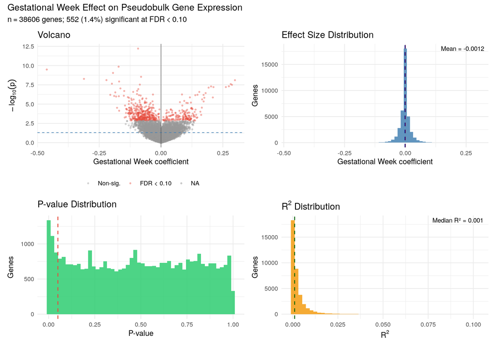

```r
plot_covariate_summary(
  results_gw,
  covariate_label = "Gestational Week",
  alpha           = 0.10,
  output_dir      = file.path(root, "results/gene-hormone/covariate_analysis"),
  filename_base   = "GW_regression_summary"
)
```

### Top Genes

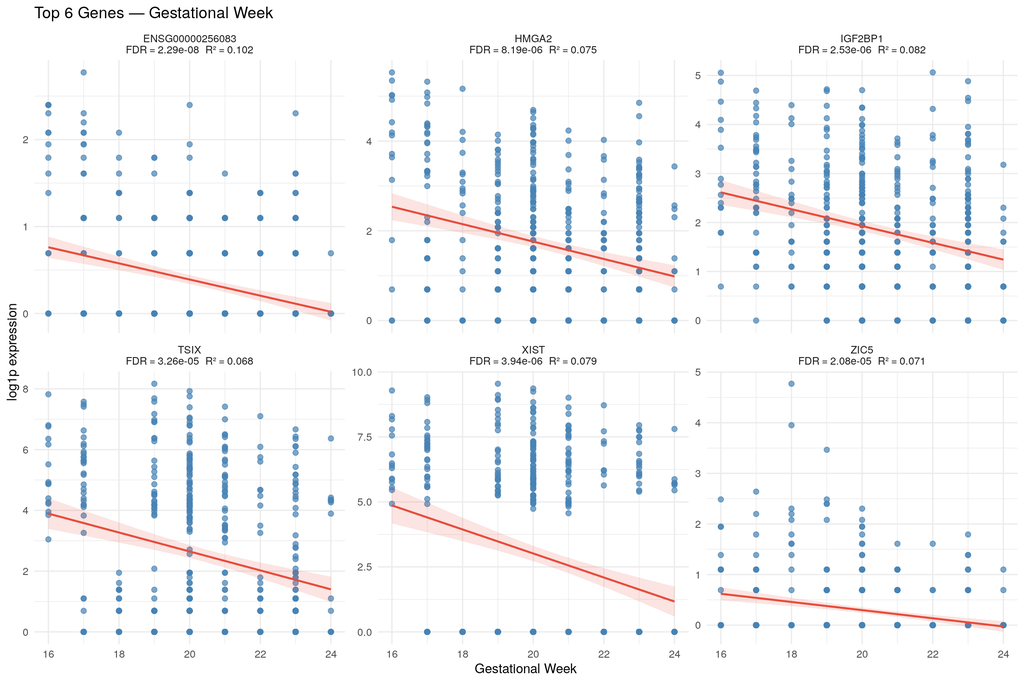

```r
plot_top_genes_continuous(
  pb_total,
  results         = results_gw,
  covariate       = "GW",
  covariate_label = "Gestational Week",
  n_genes         = 6,
  output_dir      = file.path(root, "results/gene-hormone/covariate_analysis"),
  filename_base   = "GW_top_genes"
)
```

## Cell Count

Does the number of cells aggregated per pseudobulk sample predict gene expression?

::: smallest Note that `pb_total$logcounts` is log1p of raw summed counts with no library size normalization, so some association with cell_count is expected by construction and does not indicate a meaningful biological or technical effect — voom handles depth normalization internally.

Does cell_count correlate with hormone expression or GW, making it a confound in the limma models?

::: smallest Confounding requires correlation with both the outcome (gene expression) and the predictor (hormone/GW).

```r
results_cc <- perform_regression(pb_total, "cell_count", "Cell Count")
```

```
## Running regression: 38606 genes ~ 'Cell Count' (continuous) in Pseudobulk
##   1000 / 38606 (3%)
##   2000 / 38606 (5%)
##   3000 / 38606 (8%)
##   4000 / 38606 (10%)
##   5000 / 38606 (13%)
##   6000 / 38606 (16%)
##   7000 / 38606 (18%)
##   8000 / 38606 (21%)
##   9000 / 38606 (23%)
##   10000 / 38606 (26%)
##   11000 / 38606 (28%)
##   12000 / 38606 (31%)
##   13000 / 38606 (34%)
##   14000 / 38606 (36%)
```

[output cut: 25 more lines]

```r
summarize_regression_results(results_cc, "Cell Count", alpha = 0.10)
```

```
##
## === CELL COUNT ===
##   Genes tested      : 38606
##   Sig. FDR < 0.10  : 34690 (89.9%)
##   Positive effect   : 34687
##   Negative effect   : 3
##
## Top 10:
##      gene estimate    p_value adj_p_value r_squared
##   FAM133B 0.002919 2.063e-129  7.550e-125    0.7045
##   CSNK1A1 0.003074 9.347e-129  1.711e-124    0.7026
##    SRSF11 0.002891 8.709e-128  1.063e-123    0.6998
##  GPATCH2L 0.002949 1.028e-126  9.409e-123    0.6967
##      JAK1 0.003007 1.752e-126  1.069e-122    0.6961
##    U2SURP 0.002816 1.745e-126  1.069e-122    0.6961
##      RSF1 0.002881 4.451e-126  2.327e-122    0.6949
##       MFF 0.002879 1.694e-125  6.909e-122    0.6932
##      NKTR 0.003001 1.699e-125  6.909e-122    0.6932
##     RAB2A 0.002802 5.227e-125  1.913e-121    0.6918
```

```r
write.csv(
  results_cc,
  file.path(root, "results/gene-hormone/covariate_analysis/results_cellcount_regression.csv"),
  row.names = FALSE
)
```

```r
cor(
  pb_total$metadata[, c("cell_count", "GW", "TT", "E2", "P4")],
  use = "pairwise.complete.obs"
) %>% round(2)
```

```
##            cell_count    GW   TT    E2    P4
## cell_count       1.00 -0.01 0.00 -0.01  0.01
## GW              -0.01  1.00 0.08 -0.33 -0.37
## TT               0.00  0.08 1.00  0.29  0.03
## E2              -0.01 -0.33 0.29  1.00  0.76
## P4               0.01 -0.37 0.03  0.76  1.00
```

::: fragment **Conclusion:** All correlations between `cell_count` and hormone/GW variables are negligible (|r| ≤ 0.02). Cell count is not a confound and will **not** be included as a covariate in limma-voom models. Depth normalization is handled internally by voom.

::: panel-tabset ### Diagnostic Plots

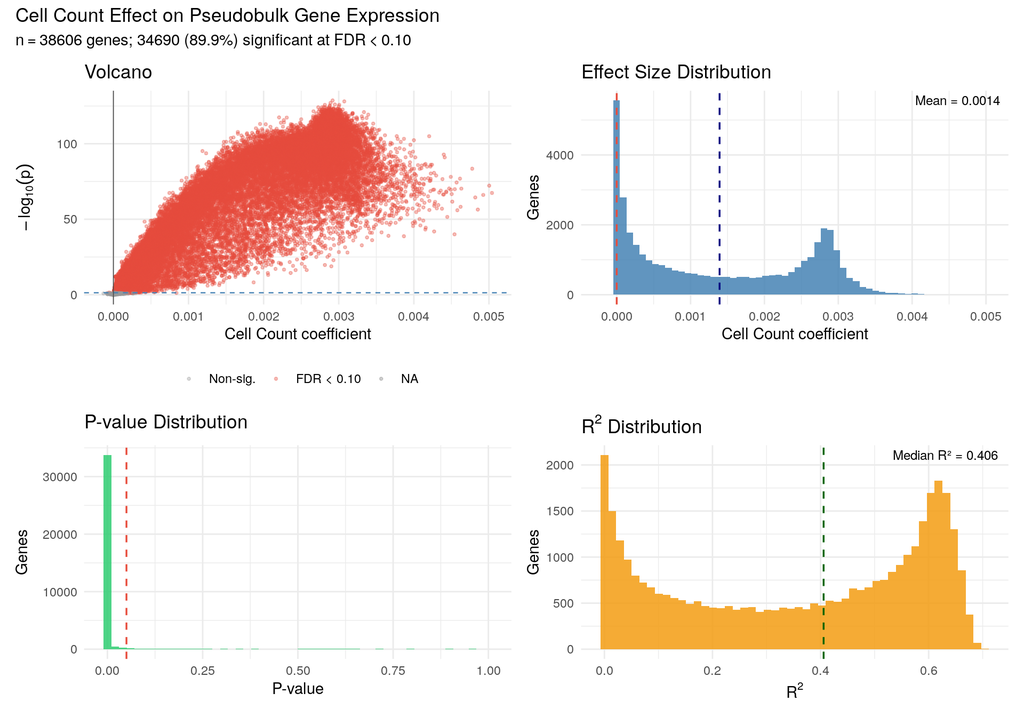

```r
plot_covariate_summary(
  results_cc,
  covariate_label = "Cell Count",
  alpha           = 0.10,
  output_dir      = file.path(root, "results/gene-hormone/covariate_analysis"),
  filename_base   = "CellCount_regression_summary"
)
```

### Top Genes

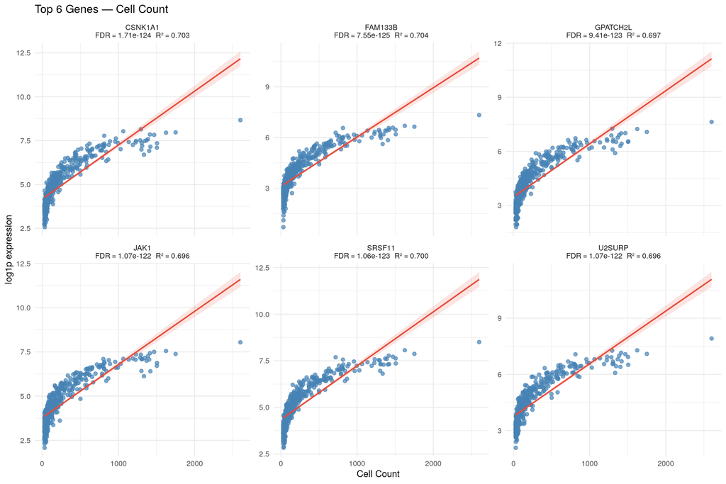

```r
plot_top_genes_continuous(
  pb_total,
  results         = results_cc,
  covariate       = "cell_count",
  covariate_label = "Cell Count",
  n_genes         = 6,
  output_dir      = file.path(root, "results/gene-hormone/covariate_analysis"),
  filename_base   = "CellCount_top_genes"
)
```

## Sex

Does biological sex (XX / XY) predict pseudobulk gene expression?

::: smallest Reference level: `F` (XX). Positive estimates indicate higher expression in XY samples.

```r
results_sex <- perform_regression(pb_total, "Sex", "Sex")
```

```
## Categorical covariate 'Sex' -- reference level: 'F'
## Running regression: 38606 genes ~ 'Sex' (categorical) in Pseudobulk
##   1000 / 38606 (3%)
##   2000 / 38606 (5%)
##   3000 / 38606 (8%)
##   4000 / 38606 (10%)
##   5000 / 38606 (13%)
##   6000 / 38606 (16%)
##   7000 / 38606 (18%)
##   8000 / 38606 (21%)
##   9000 / 38606 (23%)
##   10000 / 38606 (26%)
##   11000 / 38606 (28%)
##   12000 / 38606 (31%)
##   13000 / 38606 (34%)
```

[output cut: 26 more lines]

```r
summarize_regression_results(results_sex, "Sex", alpha = 0.10)
```

```
##
## === SEX ===
##   Genes tested      : 38606
##   Sig. FDR < 0.10  : 213 (0.6%)
##   Positive effect   : 201
##   Negative effect   : 12
##
## Top 10:
##             gene estimate    p_value adj_p_value r_squared
##             XIST   -6.627 7.644e-314  2.798e-309    0.9494
##             TSIX   -4.538 7.348e-199  1.345e-194    0.8479
##              UTY    4.229 4.208e-183  5.134e-179    0.8232
##           NLGN4Y    4.268 2.229e-169  2.040e-165    0.7984
##  ENSG00000290853    3.937 5.683e-160  4.160e-156    0.7794
##            USP9Y    4.205 1.304e-157  7.958e-154    0.7744
##           TTTY14    3.884 3.724e-129  1.947e-125    0.7037
##           TXLNGY    2.874 1.223e-126  5.596e-123    0.6965
##            KDM5D    3.011 1.433e-126  5.829e-123    0.6963
##            DDX3Y    2.852 3.232e-126  1.183e-122    0.6953
```

```r
write.csv(
  results_sex,
  file.path(root, "results/gene-hormone/covariate_analysis/results_sex_regression.csv"),
  row.names = FALSE
)
```

::: panel-tabset ### Diagnostic Plots

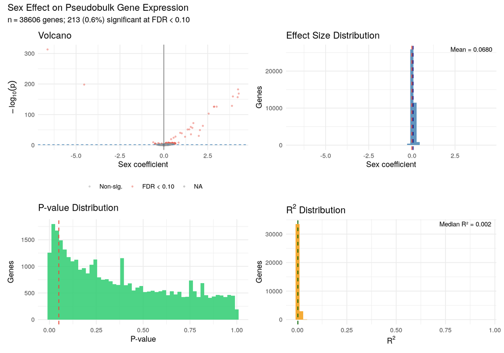

```r
plot_covariate_summary(
  results_sex,
  covariate_label = "Sex",
  alpha           = 0.10,
  output_dir      = file.path(root, "results/gene-hormone/covariate_analysis"),
  filename_base   = "Sex_regression_summary"
)
```

### Top Genes

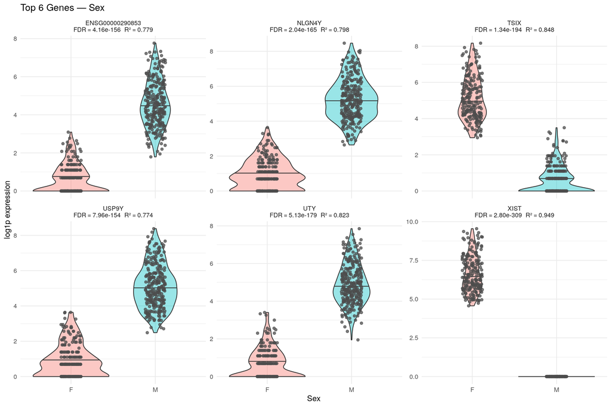

```r
plot_top_genes_categorical(
  pb_total,
  results         = results_sex,
  covariate       = "Sex",
  covariate_label = "Sex",
  n_genes         = 6,
  output_dir      = file.path(root, "results/gene-hormone/covariate_analysis"),
  filename_base   = "Sex_top_genes"
)
```

## Batch

```r
# Visualise batch1_frac across all biological samples
cat("batch1_frac summary:\n")
```

```
## batch1_frac summary:
```

```r
print(summary(batch_props_sample$batch1_frac))
```

```
##    Min. 1st Qu.  Median    Mean 3rd Qu.    Max.
##  0.0000  0.1968  0.4447  0.4134  0.5568  1.0000
```

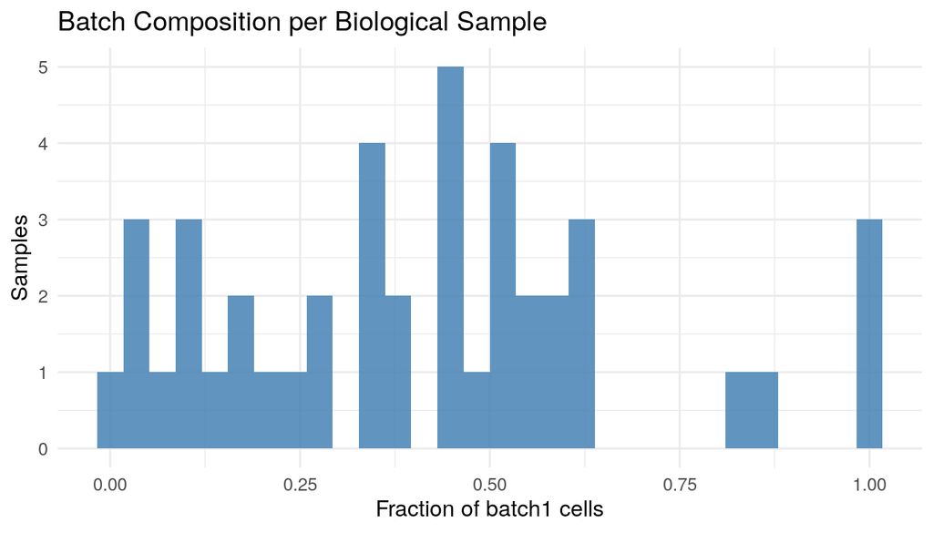

```r
ggplot(batch_props_sample, aes(x = batch1_frac)) +
  geom_histogram(bins = 30, fill = "steelblue", color = NA, alpha = 0.85) +
  labs(
title    = "Batch Composition per Biological Sample",
x        = "Fraction of batch1 cells",
y        = "Samples"
  ) +
  theme_minimal(base_size = 12)
```

```r
print(batch_props_sample)
```

```
## # A tibble: 43 × 2
##    Sample         batch1_frac
##    <chr>                <dbl>
##  1 SSD01_tissue1       0.514
##  2 SSD02_tissue2       0.142
##  3 SSD03_tissue3       0.231
##  4 SSD06_tissue6       0.630
##  5 SSD07_tissue7       0.445
##  6 SSD08_tissue8       0.0572
##  7 SSD09_tissue9       0.116
##  8 SSD10_tissue10      0.162
##  9 SSD11_tissue11      0.533
## 10 SSD12_tissue12      0.873
## # ℹ 33 more rows
```

```r
# Test whether batch1_frac correlates with biological variables of interest.
# Sex must be numeric for cor(); F=1, M=2 (alphabetical factor order).
batch_cor <- pb_total$metadata %>%
  dplyr::mutate(Sex_numeric = as.integer(factor(Sex))) %>%
  dplyr::select(GW, TT, E2, P4, Sex_numeric, batch1_frac) %>%
  cor(use = "pairwise.complete.obs") %>%
  round(2)

print(batch_cor)
```

```
##                GW   TT    E2    P4 Sex_numeric batch1_frac
## GW           1.00 0.08 -0.33 -0.37        0.27        0.12
## TT           0.08 1.00  0.29  0.03        0.24        0.04
## E2          -0.33 0.29  1.00  0.76       -0.22       -0.08
## P4          -0.37 0.03  0.76  1.00       -0.12       -0.14
## Sex_numeric  0.27 0.24 -0.22 -0.12        1.00        0.12
## batch1_frac  0.12 0.04 -0.08 -0.14        0.12        1.00
```

Does `batch1_frac` predict pseudobulk gene expression at the transcriptome-wide level, justifying inclusion as a covariate?

```r
results_batch1_frac <- perform_regression(pb_total, "batch1_frac", "Batch1 Fraction")
```

```
## Running regression: 38606 genes ~ 'Batch1 Fraction' (continuous) in Pseudobulk
##   1000 / 38606 (3%)
##   2000 / 38606 (5%)
##   3000 / 38606 (8%)
##   4000 / 38606 (10%)
##   5000 / 38606 (13%)
##   6000 / 38606 (16%)
##   7000 / 38606 (18%)
##   8000 / 38606 (21%)
##   9000 / 38606 (23%)
##   10000 / 38606 (26%)
##   11000 / 38606 (28%)
##   12000 / 38606 (31%)
##   13000 / 38606 (34%)
##   14000 / 38606 (36%)
```

[output cut: 25 more lines]

```r
summarize_regression_results(results_batch1_frac, "Batch1 Fraction", alpha = 0.10)
```

```
##
## === BATCH1 FRACTION ===
##   Genes tested      : 38606
##   Sig. FDR < 0.10  : 2880 (7.5%)
##   Positive effect   : 2727
##   Negative effect   : 153
##
## Top 10:
##       gene estimate   p_value adj_p_value r_squared
##    SLC26A3  -3.1053 6.919e-16   2.533e-11   0.12681
##  LINC02479  -2.3306 3.905e-15   7.146e-11   0.12059
##       PAX3  -1.4885 9.238e-15   1.127e-10   0.11748
##     TUBB2A   2.0727 1.333e-10   6.972e-07   0.08228
##   PPP1R14B   1.8872 1.249e-10   6.972e-07   0.08253
##     PET100   1.7287 1.238e-10   6.972e-07   0.08256
##  CEACAM22P   1.1444 8.279e-11   6.972e-07   0.08406
##       F8A1   0.9843 2.376e-10   1.087e-06   0.08012
##     RPL18A   2.0000 2.996e-10   1.219e-06   0.07926
##       SPRN   1.3405 3.481e-10   1.274e-06   0.07870
```

```r
write.csv(
  results_batch1_frac,
  file.path(root, "results/gene-hormone/covariate_analysis/results_batch1frac_regression.csv"),
  row.names = FALSE
)
```

::: panel-tabset ### Diagnostic Plots

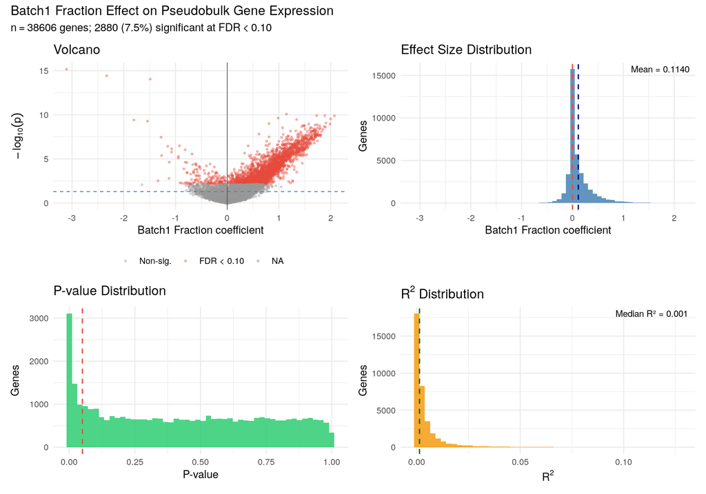

```r
plot_covariate_summary(
  results_batch1_frac,
  covariate_label = "Batch1 Fraction",
  alpha           = 0.10,
  output_dir      = file.path(root, "results/gene-hormone/covariate_analysis"),
  filename_base   = "Batch1Frac_regression_summary"
)
```

### Top Genes

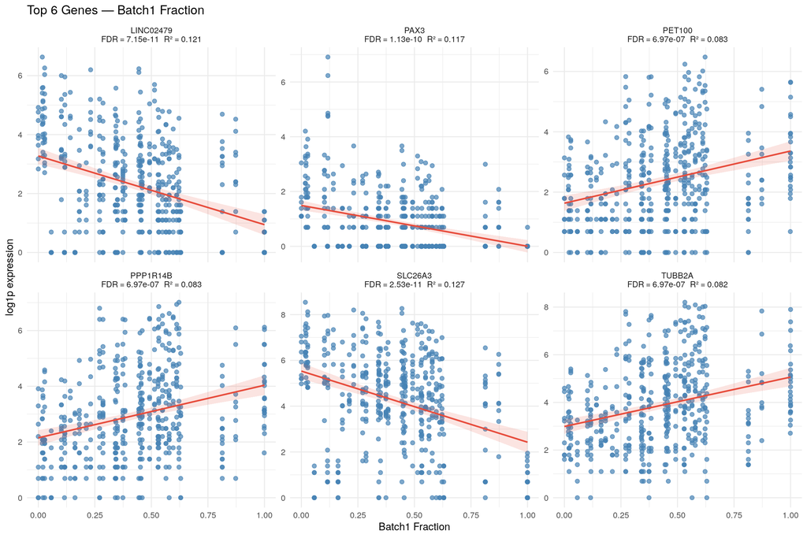

```r
plot_top_genes_continuous(
  pb_total,
  results         = results_batch1_frac,
  covariate       = "batch1_frac",
  covariate_label = "Batch1 Fraction",
  n_genes         = 6,
  output_dir      = file.path(root, "results/gene-hormone/covariate_analysis"),
  filename_base   = "Batch1Frac_top_genes"
)
```

## Summary

```r
covariate_summary <- tibble::tibble(
  Covariate = c("Gestational Week", "Cell Count", "Sex", "Batch1 Fraction"),
  Type = c("Continuous", "Continuous", "Categorical", "Continuous"),
  `Genes Tested` = c(
nrow(results_gw),
nrow(results_cc),
nrow(results_sex),
nrow(results_batch1_frac)
  ),
  `Sig. (FDR < 0.10)` = c(
sum(results_gw$adj_p_value < 0.10, na.rm = TRUE),
sum(results_cc$adj_p_value < 0.10, na.rm = TRUE),
sum(results_sex$adj_p_value < 0.10, na.rm = TRUE),
sum(results_batch1_frac$adj_p_value < 0.10, na.rm = TRUE)
  )
) %>%
  dplyr::mutate(
`% Sig.` = round(100 * `Sig. (FDR < 0.10)` / `Genes Tested`, 1),
`Median R²` = round(c(
  median(results_gw$r_squared, na.rm = TRUE),
  median(results_cc$r_squared, na.rm = TRUE),
  median(results_sex$r_squared, na.rm = TRUE),
  median(results_batch1_frac$r_squared, na.rm = TRUE)
), 4)
  )

knitr::kable(covariate_summary)
```

| Covariate | Type | Genes Tested | Sig. (FDR < 0.10) | % Sig. | Median R² |
| --- | --- | --- | --- | --- | --- |
| Gestational Week | Continuous | 38606 | 552 | 1.4 | 0.0010 |
| Cell Count | Continuous | 38606 | 34690 | 89.9 | 0.4056 |
| Sex | Categorical | 38606 | 213 | 0.6 | 0.0021 |
| Batch1 Fraction | Continuous | 38606 | 2880 | 7.5 | 0.0013 |

::: fragment **Interpretation:** Sample level covariates where a substantial fraction of genes reach FDR < 0.10 — or where the p-value histogram shows enrichment near 0 — exert transcriptome-wide influence and should be included as additive terms in limma-voom models. Potential confounders such as Batch and Cell Count were assessed separately and determined to not be directly related to variables of interest.

## AI Assistance Disclosure

Code in this script was developed with assistance from Claude (Anthropic). All AI-generated code was reviewed, validated, and adapted by the author.